# AMJ20240178_proof.pdf

Converted from PDF `Allen-UserCommunityFeedback-2026-AMJ.pdf` · 30 pages · anchors: page `#pN`, block `#pN-bK`

Page 1

### LISTEN TO YOUR USERS? SELF-SELECTION

### IN USER COMMUNITY FEEDBACK AND

### COMMERCIAL IMPACT

RYAN T. ALLEN Brigham Young University

ROBERT BREMNER

Stanford University

RORY M. MCDONALD

University of Virginia

Firms increasingly involve user communities in product development, and prior research documents many benefits in idea generation, knowledge sharing, and cost reduction. We theorize, however, that incorporating market feedback about products from these communities can harm products’ commercial performance. Because community feedback is volunteered by self-selected participants rather than sampled to represent the broader market, it may mislead firms when narrow community preferences diverge from mainstream demand. We predict that greater incorporation of community feedback will increase positive evaluations of a product within the community, but undermine its broader commercial success when there are strong user self-selection pressures (like for initially niche-targeted games). We test this theory in the personal-computer (PC) video-game industry using Steam Early Access, where developers integrate community feedback prior to release. Using a multimethod design that combines large-scale archival analyses with interviews of developers, executives, and community members, we find that feedback incorporation during Early Access improves post-launch commercial outcomes of games only when the Early Access community closely mirrors the distribution of users in the broader Steam market. However, in unrepresentative communities—even large ones—greater incorporation predicts lower post-launch revenues despite favorable community evaluations.

Firms increasingly turn to user communities for guidance in new product development. User communities are informal groups of self-selected volunteers who, collaboratively and with minimal oversight, contribute to products or technologies (Lakhani & von Hippel, 2003; Mollick, 2016; O’Mahony & Lakhani, 2011; Shah, 2006). Because user communities’ strengths complement traditional firms’ capabilities (Baldwin & von Hippel, 2011; Bremner & Eisenhardt, 2021; Felin & Zenger, 2014), scholars argue that the “engines of innovative activity,” historically residing within firms, now reside within firm– community interactions (Harhoff & Lakhani, 2016; O’Mahony & Lakhani, 2011; Shah & Nagle, 2020: 308).

Prior work has identified many benefits for firms that engage user communities at various stages of innovation. For instance, engaging with user communities boosts creative idea generation (Bayus, 2013; Lilien, Morrison, Searls, Sonnack & Hippel, 2002; Park, Piezunka & Dahlander, 2024; Piezunka & Dahlander, 2015, 2019; Poetz & Schreier, 2012; Schweisfurth, 2017), expands knowledge access in new technology development (Dahlander & Magnusson, 2005; Dahlander & Wallin, 2006; Nagle, 2018, 2019), and reduces development and commercialization costs (Baldwin, Hienerth & von Hippel, 2006; Bremner & Eisenhardt, 2021; Shah & Tripsas, 2007). These studies converge on the conclusion that engaging with user communities benefits firms seeking to innovate across multiple stages of the innovation process.

However, we develop theory that describes the circumstances under which incorporating user

The authors are grateful to Goerg von Krogh for his immensely helpful feedback throughout the editorial process.

Accepted by Georg von Krogh

1

r Academy of Management Journal 2026, Vol. 00, No. 00, 1–29. https://doi.org/10.5465/amj.2024.0178

Page 2

community preferences during the market feedback<sup>1</sup>

stage of innovation can undermine the commercial success of firms’ products. Our theory builds on a key insight: unlike traditional market research, in which respondents are intentionally sampled or recruited to match a target audience, user community feedback is volunteered by self-selecting users (Harhoff & Lakhani, 2016; Lakhani & von Hippel, 2003; O’Mahony & Lakhani, 2011; Shah, 2006; Shah & Nagle, 2020; Von Krogh, Haefliger, Spaeth & Wallin, 2012). The very strengths of communities in other firm– community interactions—their enthusiasm and experience—create sample-selection issues when incorporating market feedback. If the most eager participants differ systematically from the broader market, then even large volumes of community feedback can be misleading rather than informative. For products with strong self-selection pressures (like initially niche-targeted products), incorporating feedback that caters to “what the community wants” will likely misalign with “what the broader market will buy.” Therefore, while incorporating more feedback from an unrepresentative community will increase positive within-community evaluations,<sup>2</sup> this self-selection can create a scenario in which incorporating more feedback systematically diminishes the product’s broader commercial performance.

We test our theory in the context of PC video-game development. We analyze games available through Steam Early Access, a program that allows developers (firms) to incorporate feedback from dedicated user communities to refine features and tune balance and

difficulty before official release. We conduct a multimethod investigation using multiple large archival samples of Steam Early Access games supplemented by interviews with game developers, industry executives, and community members. We measure feedback incorporation as the textual similarity between developer (firm) announcements and user reviews during Early Access; we measure community representativeness as the extent to which the distribution of user types during Early Access mirrors the broader distribution of user types on Steam.

We find no association, on average, between firms’ feedback incorporation and their products’ commercial success. However, as our theory anticipates, we find significant heterogeneous effects driven by strong negative moderation from community unrepresentativeness. For games with unrepresentative communities (even large ones), incorporating more feedback from the community decreases commercial success (post-Early Access revenue), even as it increases positive within-community evaluations (positive ratings within the initial Early Access feedback community). However, for games with representative communities, feedback incorporation has a positive effect on commercial success. We observe a similar pattern for games with a high proportion of “power users” (the most frequent Early Access participants)—games that heavily incorporate this feedback are less commercially successful. We also investigate why firms would use such feedback if it is hurting commercial success. We find no significant relationship between the degree of community unrepresentativeness and the extent of feedback incorporation, strongly suggesting that detecting and adapting to unrepresentative feedback is challenging for firms.

The idea that unrepresentative samples can lead to incorrect inferences is well-established (Cao, Koning & Nanda, 2021; Denrell, 2003; Denrell & Kovacs, 2008). Yet, our findings emphasize that in product development with user community feedback, the degree of unrepresentativeness can be systematic (not merely noisy), difficult to detect, and challenging to mitigate. Crucially, this is not a problem that is solved by “more data” from the community: with strong selfselection into feedback, larger samples will still converge toward the preferences of the community rather than those of the broader market. This risk is most acute for products that initially attract niche user types; when the feedback community mirrors the broader market, incorporating more feedback improves both within-community evaluations and commercial performance.

1 Firms soliciting market feedback from communities in product development is an increasingly common form of firm–community interaction in which the user community helps to validate and refine product features (Shah & Nagle, 2020). Instead of generating new product ideas or contributing to the initial development of a technology, the community provides feedback on the most valuable features and functionalities of a firm’s partially developed product. Examples include online product forums, such as the r/YNAB subreddit for users of a popular budgeting app, community discussions with founders on crowdfunding platforms like Kickstarter, and early-release platforms like those for new games on Epic and Roblox.

2 “Positive within-community evaluations” refer to the extent to which members of a community like, enjoy, and consequently give favorable reviews or assessments of a product. This is distinct from commercial success: a small community may hold the product in high regard (strong positive within-community evaluations), but if their preferences do not generalize, demand outside the community may remain limited.

2 Academy of Management Journal Month

Page 3

These findings make three theoretical contributions. First, we extend the literature on user community innovation by highlighting an underappreciated boundary condition of the benefits of firm– community interaction: market feedback from selfselected community members can bias development toward within-community preferences. Second, we break with the prevailing assumption in entrepreneurship that more and richer market information improves learning. Third, we identify an important boundary condition in the literature on open organizational forms: while search with external users mitigates supply-side myopia, the self-selection of external users can systematically skew demand-side learning.

THEORY AND HYPOTHESES

Self-Selection and User Community Feedback

User communities are, by definition, characterized by open membership and self-selection into participation (Lakhani, 2016; Lakhani & von Hippel, 2003; Mollick, 2016; Shah, 2006; Shah & Nagle, 2020). Prior research on user community innovation has documented extrinsic and intrinsic motivations for participation in communities (see Von Krogh et al., 2012). Intrinsic motivations include enthusiasm for the new product or technology (David & Shapiro, 2008; Lakhani & von Hippel, 2003), the joy of participation (Hippel & Krogh, 2003; Shah, 2006), altruism (Osterloh & Rota, 2007), and belonging within a group of like-minded individuals (Lakhani & Wolf, 2005). Participants also face internalized extrinsic motivations such as attaining reputation and status within the community (Krishna, Shrestha & Von Krogh, 2024; Lakhani & von Hippel, 2003; Lakhani & Wolf, 2005), reciprocity with other contributors (David & Shapiro, 2008; Lakhani & von Hippel, 2003), or the need for a product or technology that does not exist elsewhere (David & Shapiro, 2008; Shah, 2006). While many such studies examine communities building technological solutions such as opensource software, other studies identify similar motivations in crowdsourcing communities contributing feedback and ideas to firms (Bayus, 2013; Harhoff & Lakhani, 2016; Preece, Nonnecke & Andrews, 2004). Though motivations like self-determination may be less common than in open-source software development, enthusiasm for the domain, altruism, participatory enjoyment, and product necessity still motivate users providing feedback to firms (Lakhani, 2016).

Potential Benefits of User Community Feedback

Prior research on user community innovation has not directly examined whether incorporating selfselected user community enhances the commercial success of firms’ products. However, research on entrepreneurial innovation (not based in user communities) broadly supports the idea that incorporating early customer feedback increases the likelihood of developing commercially successful products (Allen & McDonald, 2025; Camuffo, Cordova, Gambardella & Spina, 2020; Contigiani & Levinthal, 2019; Koning, Hasan & Chatterji, 2022; McDonald & Gao, 2019). Soliciting feedback helps firms resolve market uncertainty by understanding customer preferences (Camuffo et al., 2020; McDonald & Eisenhardt, 2019; Murray & Tripsas, 2004; Toh & Kim, 2013), guiding product design decisions such as which features will attract a sufficiently large audience (MacCormack, Verganti & Iansiti, 2001).

Extrapolating from several strands of research focused on innovation phases like ideation and development suggests that feedback from self-selected communities could benefit firms seeking commercial success. Studies on user community innovation show that members who voluntarily join communities are highly motivated to enhance the focal technology or product (Lakhani, 2016; Mollick, 2016; O’Mahony, 2003; Shah, 2006; Von Krogh, Spaeth & Lakhani, 2003). Assuming that similar motivations drive community members providing feedback on products, we expect them to contribute more time and insight compared to typical market research participants.

Furthermore, studies on user-led innovation indicate that product users with actual experience using a product (or similar products) possess more knowledge about useful features through deeper, sustained interaction (Chatterji & Fabrizio, 2014; Foss, Laursen & Pedersen, 2011; Katila, Thatchenkery, Christensen & Zenios, 2017). For example, Chatterji and Fabrizio’s (2014) longitudinal analysis of 128 medical-device firms finds that firms collaborating with users (physicians, in their case) during the innovation process are more likely to produce radical innovations (for a similar conclusion in corporate venture capital, see Smith & Shah 2013). Given that community feedback comes from users who self-select into interacting with and thus gaining experience with the product, similar benefits could apply to user community feedback.

Relatedly, studies establish that lead users with the highest demand for, or understanding of, new products—though unrepresentative of the broader population—provide particularly novel and valuable

2026 Allen, Bremner, and McDonald 3

Page 4

ideas to firms (Lilien et al., 2002; Schweisfurth, 2017; Urban & von Hippel, 1988; von Hippel, 1986). For instance, Lilien et al. (2002) illustrate 3M’s “lead user process”: the firm collected information from cuttingedge lead users about needs and solutions to advance internal innovation efforts, which resulted in more novel ideas that 3M managers deemed had higher commercial potential than ideas generated internally or by representative user samples (see also Urban & von Hippel, 1988). If leading users self-select into communities, feedback from user communities may offer similar advantages.

These positive effects may compound by engaging a large number of users. Crowdsourcing research shows that sourcing ideas from beyond a firm’s boundaries can overcome constraints of internal innovation (Afuah & Tucci, 2012; Bayus, 2013; Park et al., 2024; Piezunka & Dahlander, 2015, 2019; Poetz & Schreier, 2012). These constraints include limited cognitive diversity, organizational inertia, and a notinvented-here bias, all stymying innovative thinking and responsiveness to market changes. Dell’s Idea- Storm program, documented by Bayus (2013), exemplifies this approach by soliciting a wide array of user-generated ideas. The program tapped into the diverse and passive creative potential of Dell’s user base, gathering thousands of submissions, which were then rigorously evaluated to identify and implement the most promising ideas. If market feedback from users follows similar patterns, these advantages should apply.

Finally, additional benefits may arise from learning within interactive user communities. Prior studies demonstrate that members engage in collaborative forums, which provide rich environments for interactive feedback and collaborative solution-building that surpass individual efforts (Autio, Dahlander & Frederiksen, 2013; Jeppesen & Molin, 2003; Shah & Tripsas, 2007). Shah and Tripsas (2007) show that successful ventures in the juvenile products industry leveraged collective creative activity with communities (through users socializing, discussing common needs, and building on others’ ideas), significantly improving the quality of innovations.

While prior studies have addressed firm– community interactions in other innovation phases (ideation, development), extrapolating their findings to market feedback contexts suggests that similar mechanisms could apply. Critical contextual caveats remain, as such studies typically focus on specialized domains like medical devices (Chatterji & Fabrizio, 2014; Katila et al., 2017), or new technological domains that are not well understood (Urban & von

Hippel, 1988). Nevertheless, without evidence to the contrary, existing user-innovation literature supports that user community feedback could enhance product quality and commercial success.

Potential Risks of Self-Selected User Community Feedback

However, when soliciting product feedback from self-selected user communities, firms face the risk of learning from unrepresentative samples. In traditional market research, firms select subjects to represent their target market when soliciting market feedback; in communities, users join and provide feedback for their own reasons, as mentioned previously (Harhoff & Lakhani, 2016; Lakhani & von Hippel, 2003; O’Mahony & Lakhani, 2011; Shah, 2006; Shah & Nagle, 2020; Von Krogh et al., 2012). This lack of control over the feedback sample raises risks of false inferences from selection bias in the user community feedback (Shah & Nagle, 2020).

Not all products attract communities whose preferences misrepresent the broader market. Communities vary in how they reflect potential customer preferences, ranging from niche-focused to broadly mainstream (Carroll, 1985; Christensen & Bower, 1996; Moore, 1991).<sup>3</sup> Products positioned toward niche markets naturally attract users whose feedback is apt to exhibit selection biases, diverging from mainstream preferences (Moore, 1991). Importantly, for our theory, a product attracting an unrepresentative community (given a similar community size) does not automatically decrease the potential for commercial success. While products attracting mainstream customers generally have the highest likelihood of commercial success (Allen, 2025; MacCormack et al., 2001), products attracting niche customers can achieve significant commercial success when (a) the market has heterogeneous needs and preferences (Riggs & von Hippel, 1994), (b) the niche market is poised to expand into a broader population (Allen, 2025; Christensen & Bower, 1996; Rogers, 2003), or (c) mainstream markets are overly competitive (Allen, 2025; Chen, Katila, McDonald & Eisenhardt, 2010;

3 As stated in this paragraph, we assume that a product’s initial positioning (i.e., design, attributes, value proposition, target audience, etc.) will determine its placement on the spectrum from niche to mainstream appeal, and that this positioning will generally correspond to the representativeness of the community attracted to giving feedback to a product. We empirically validate this assumption and explore other antecedents of community unrepresentativeness in the “Results” section.

4 Academy of Management Journal Month

Page 5

Denrell, Fang & Winter, 2003; Gavetti, 2012). Thus, we do not presuppose that a community’s unrepresentativeness (niche or mainstream orientation) directly affects commercial success.

Instead, we argue that the interaction between community unrepresentativeness and firm feedback incorporation matters. Initially attracting an unrepresentative community need not harm commercial success, but incorporating feedback from such a sample may prove detrimental. Prior research in innovation, statistics, and marketing demonstrates that inferences from unrepresentative samples can mislead firms’ learning (Cao et al., 2021; Denrell, 2003; Denrell & Kovacs, 2008; Heckman, 1979; Pritchett & Sandefur, 2015). Consider Cao et al. (2021), who examined the online platform Product Hunt, where founders, developers, and designers provide feedback on early product ideas. They found that female-targeted products launching on days with randomly more male participants had lower chances of success, suggesting that biased feedback composition distorts inferences about market potential. Similarly, Denrell (2003) argued that organizations learn harmful practices by emulating a biased sample of successful peers (firms that engaged in risky practices but survived) while ignoring failed peers. In both cases, additional information—whether user preferences or organizational practices—proved harmful when the information’s representativeness<sup>4</sup> was lacking (see also Denrell & Kovacs, 2008).

When members of a user community are predominantly a specific user type, feedback from the community may misrepresent mainstream market preferences (Moore, 1991). The more a product attracts unrepresentative users, the greater the risk that incorporating their feedback steers development toward niche features that are appealing to community members yet fail to achieve broader commercial success. This trajectory contradicts mainstream commercial success, which usually requires products to transition from niche appeal to broad market acceptance (Allen, 2025; Christensen & Bower, 1996; Moore, 1991; Rogers, 2003).

Hence, counterintuitively, more information (via community feedback) can undermine a product’s ultimate commercial success. When feedback comes from a representative sample, both positive and negative feedback prove valuable: positive feedback confirms the product is on track, while negative feedback prompts reconsideration of current features and

functionality (Allen & McDonald, 2025). However, for feedback from an unrepresentative sample, incorporating it can be detrimental, leading firms to either discard features that would attract a broader audience (Type I error) or pursue niche features that are unappealing to other potential customers (Type II error).

Consider a hypothetical scenario where a firm develops a prototype budgeting app with uniquely rich budgeting features. Due to its distinctive functionality, this app attracts a specific type of user who seeks specialized budgeting tools that are unavailable elsewhere and forms an enthusiastic community that contributes feedback to the product. Their enthusiasm for the uniquely rich features, however, becomes a double-edged sword. While these self-selected users offer valuable insights into preferences that are similar to their own, their preference for complex, featurerich interfaces skews development. Their feedback might encourage the prioritization of sophisticated features that, while valuable to them, could alienate mainstream users seeking simplicity. Rather than catering to these specialized interests, the app could achieve broader market success by adapting its niche functionality to attract casual budgeters (instead of entrenching with budgeting super-users that selected into the community).

Given the potential for systematic selection bias in community members’ preferences, increasing the sample size of the community or the volume of feedback will not correct its bias. The central limit theorem states that the mean of a sufficiently large number of random samples from a population will approximate the population mean; thus, increased sample size typically improves inference (Casella & Berger, 2024; Feller, 1991). However, a large sample of systematically unrepresentative, self-selected users (budgeting super-users) will converge not on the true population mean, but rather on the mean of that specific user type. Given a strong selection pressure for a particular type of user, preferences inferred from feedback will misrepresent the broader population, and inferences will mislead.

User Community Feedback Incorporation and Commercial Success

Thus, unlike typical market research, it remains ambiguous whether incorporating feedback from selfselected user communities will, on average, enhance or dampen the commercial success of a firm’s product. Indeed, the two theoretical traditions reviewed above suggest countervailing forces. On one hand, user feedback typically increases product performance; on the

4 We use the term “representativeness” for convenience (not as a separate construct), to mean the inverse of “unrepresentativeness.”

2026 Allen, Bremner, and McDonald 5

Page 6

other hand, such feedback may harm performance if unrepresentative users self-select into feedback participation, nudging development toward preferences that fail to transfer to the broader market of potential customers. Without empirical evidence to adjudicate which mechanism predominates for user community feedback, the average impact of feedback incorporation on commercial success remains uncertain, depending on which force dominates.

Integrating these insights, we propose that feedback incorporation’s impact on commercial success critically depends on the unrepresentativeness of the community attracted to the product (independent of the community size). Importantly, neither direct effects from feedback incorporation nor community unrepresentativeness drive our theory; we do not hypothesize their direction (see Figure 1). Instead, we hypothesize a negative moderating effect such that incorporating feedback for a product that attracts an unrepresentative community will dampen a product’s commercial success, even with a large sample. Formally, we hypothesize:

Hypothesis 1. Incorporating user community feedback decreases a product’s commercial success when the community is unrepresentative of the broader market.

User Community Feedback Incorporation and Positive Within-Community Evaluations

As our main hypothesis suggests, some products attract communities composed of unrepresentative

users. When firms heavily incorporate feedback from these users, they may cater to atypical preferences while alienating users outside the community. The firms risk tailoring products too strongly to salient community feedback, while neglecting potential customers outside the community, decreasing commercial success.

However, incorporating community feedback should still increase community members’ satisfaction with the product. This creates a boundary condition for our theorizing. Unlike achieving commercial success outside the community, incorporating community feedback should unambiguously increase within-community evaluations, regardless of the community’s representativeness of the broader market. Generating positivity within the community requires no appeal to users beyond those who provided the feedback. Catering to users who gave feedback should make those users more positive about the product (Allen & McDonald, 2025; Camuffo et al., 2020; Gans, Stern & Wu, 2019; Koning et al., 2022; Morris, Oldroyd, Allen, Chng & Han, 2023), whether feedback is unrepresentative or representative.

A corollary to the logic underlying Hypothesis 1, then, is that incorporating unrepresentative users’ feedback should increase positive within-community evaluations—how much the users who provided feedback enjoy and positively rate the product. If feedback incorporation failed to enhance within-community evaluations, our theory would be questioned.

Therefore, while feedback incorporation from an unrepresentative community decreases commercial

FIGURE 1 Theoretical Framework

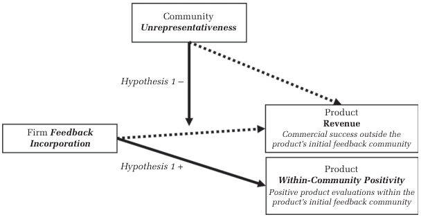

NOTE: figure/graphic rendered as an image from the PDF; its content is not machine-readable text. Caption (if any) follows as the next block.

**text found inside the figure**

Community *Unrepresentativeness*

Firm *Feedback*

*Incorporation*

Product **Revenue**

Product *Within-Community Positivity*

*Hypothesis 1* –

*Commercial success outside the product’s initial feedback community*

*Positive product evaluations within the*

*product’s initial feedback community*

Note: Solid lines illustrate the hypothesized effects. Dashed lines represent direct effects, which are not directly hypothesized.

6 Academy of Management Journal Month

Page 7

success (Hypothesis 1), we theorize a divergent effect of feedback incorporation on within-community evaluations independent of community representativeness. We hypothesize:

Hypothesis 2. Incorporating user community feedback increases positive within-community evaluations of the product, regardless of community representativeness of the broader market.

Figure 1 displays our theoretical framework. The solid lines represent hypothesized effects, while the direction of the average effect of the dashed lines indicate non-hypothesized relationships that are outside our theoretical focus.

METHODS

Setting

We test our hypotheses in the setting of PC videogame development. The video-game industry, which originated in the 1970s, has become a major economic sector: its global revenue in 2018 was reported to be approximately $138 billion (Wijman, 2018). Of this total, PC game sales accounted for approximately 24%.

To conduct our analysis, we collected data on video games hosted by Steam Early Access. Steam, the leading online digital distribution platform for PC games, was launched in 2003 by Valve, a successful video-game developer and publisher (Plunkett, 2013). Firms can list games on the Steam Store in exchange for a share of sales revenue of up to 30%. In 2018, the Steam Store listed over 27,000 games for sale (Meer, 2019). Analysts estimate that PC game sales via Steam represent around 60% of global industry sales (Edwards, 2013; Hruska, 2018).

Steam offers Early Access as a specialized platform for firms “to develop your game with the community by giving them access to your title before it is officially released” (Steamworks, 2014). Early Access “encourages ongoing updates from [firms], while letting players participate in direct feedback through gameplay and community involvement” (Steam, n.d.). Based on our interviews and data, firms tend to use Early Access for smaller one-off “indie” games (as opposed to AAA or franchise games), or games with high “replay value” (as opposed to linear storyline games). This tends to include games in genres like grand strategy, simulations, and online multiplayer games, where changes to features and balance can significantly alter the game, giving Early Access considerable influence on its commercial success. We note that our findings with respect to unrepresentativeness and the degree of feedback incorporation should be

interpreted in the context of products that opt in to collaboration with user communities (rather than comparing products that do vs. do not opt in to collaborating with communities in the first place).

Consistent with the literature on user communities (Puranam, Alexy & Reitzig, 2014; Shah, 2005, 2006), any user can join and participate in Steam Early Access communities, whether they play the games or not. As is typical of user communities that form around new products, users participate not because the games are the best, most polished games available—for that, they can buy fully developed games—but because they exhibit motivations similar to those seen in prior studies of communities (Shah, 2006; Von Krogh et al., 2012). “Early Access games are a lot more fun to play,” one user explained. “They are typically much more innovative. [Big-budget, heavily marketed] titles are so incremental; they just improve the graphics or add a few new features to the same old formula.” Another motivation is social interaction (David & Shapiro, 2008). As one user explained: “The community is what makes [Early Access games] fun to play for me. It’s a social experience.” A third motivation expressed by users is altruism and a sense of belonging (Osterloh & Rota, 2007; Von Krogh et al., 2012); in one user’s words: “There is a certain joy in responding in forums and giving suggestions and feedback to [firms], and then seeing your ideas being implemented.”

By listing a game on Early Access, firms can incorporate community feedback to potentially improve the game. The firm is not formally obliged to maintain, change, or even complete the game. As a manager in one firm recounted:

We launched [our game] in Early Access with about an hour of gameplay. It was enough to give the player a decent experience right away. But it also gave us an opportunity to really incorporate [community] feedback as we continued to work on the game.

Firms also participate in discussions and rely on the community for feedback, which is typically viewed as valuable in development. As a game designer in another firm observed, “Listening to the community is extremely important. There were a couple of times where we ignored what the community was telling us, and I think that was a big mistake.”

Steam Early Access is an attractive setting for our research for two reasons. First, market feedback is the key objective of Early Access (Steamworks, 2014). Users provide ideas to firms (e.g., for features or game balance) through reviews and forums, but users do not directly create or modify the games themselves.

2026 Allen, Bremner, and McDonald 7

Page 8

Feedback is perceived as valuable because the videogame industry is characterized by extreme market uncertainty (Katila, Piezunka, Reineke & Eisenhardt, 2022). In our interviews, one developer at a prominent firm aptly commented, “Nobody knows how to always make a hit game.” Releasing an incomplete game during the experimental, early access phase thus enables firms to tweak and test a game’s design and its reception.

A second reason why Steam Early Access is an attractive research setting is that every Early Access game has its own user community—a collection of individuals with a shared interest in a particular Early Access game (Lakhani, 2016; Shah & Tripsas, 2007). This scenario allows us to create a large sample of user communities linked to specific games, which allows quantitative analysis and observation of game outcomes over time.

Data

We created multiple datasets to test our results. The primary datasets, which contain the highest level of detail, were compiled primarily from scraping and merging data from SteamDB and SteamSpy, and include all games that entered Steam Early Access between April 2015 (when commercial-performance data became available) and March 2018 (the month before SteamSpy shut down due to changes in Steam privacy updates).<sup>5</sup> We also compiled a separate extension dataset, merging several sources, including the Video Game Insights database and the Steam application-programming interface (API), that extends through 2024. Although in some ways less granular than the primary dataset, it allows us to corroborate our main results with an independent and more up-todate data source.

Primary datasets: Built using SteamDB and SteamSpy. For our primary analysis datasets covering April 2015–March 2018, we collected quantitative data on Steam games from two primary sources: SteamDB (steamdb.info) and SteamSpy (steamspy.- com). SteamDB is an online database that uses Steam’s API to collect daily data on games’ characteristics, such as price, and on pertinent activity such as announcements and software updates. SteamSpy is

another online database that historically used Steam’s API to estimate community characteristics and performance data for each game, such as the number of active users, average playtime, and total sales. However, due to a change in Steam’s user privacy policy in April 2018, the data do not extend into recent years. SteamSpy’s pre-2018 data have been used in several prior research studies (Bailey & Miyata, 2019; Brunt, King & King, 2020; Lin, Bezemer, Zou & Hassan, 2019), and its accuracy has been confirmed by multiple game firms (Hall, 2015; Orland, 2014). See Appendix A (available at https://osf.io/8nmfj?view_ only=88d40e8e733b426abda13dc0af0118b8) for a more detailed description of SteamSpy’s datacollection process.

For our primary analysis, we processed the data to create a cross-sectional sample of games that were developed in Early Access and subsequently officially launched (for an illustration of the data structure, see Figure 2). We began by collecting a sample of all 2,507 games that were in Early Access at any point during the April 2015–March 2018 period, after excluding game expansions, free games, and add-ons to existing games (Mollick, 2012; Zhao, Ishihara, Jennings & Lounsbury, 2018).<sup>6</sup>

It was necessary to drop games from the sample for which it was not possible to calculate feedback incorporation or a community’s unrepresentativeness (our independent and moderator variables) or the outcome of post-launch commercial success (our primary dependent variable). First, games with no feedback or very limited feedback did not permit construction of a measure of community unrepresentativeness (see “Measures” section). We included only games that had received feedback from at least five reviewers during the observed Early Access period.<sup>7</sup> This reduced the sample size to 1,795 games. Second, it was not possible to include games that never provided any

5 After March 2018, Steam Spy, which collected data using user profiles (see Appendix A), was no longer able to provide quality data due to a change in Steam’s user privacy policy. During the period 2015–2018, approximately 20% of Steam games were launched via Early Access (3,247 Early Access games versus 12,804 standard games).

6 We exclude free games because they can go viral in the short term without achieving significant commercial success (Hall, 2015). The paid games in our sample may have additional in-game purchases, which we do not capture in our SteamSpy-derived measure of revenue. In the context of Early Access, it is important to note that one-time purchase games are not static after the time of purchase—they are still continually improved after purchase.

7 We use five reviewers because below five there will be a mechanical increase in unrepresentativeness (fewer than five reviewers cannot be representative of the five customer segments used to construct the measure). In Appendix D, we show that results are robust to alternative thresholds, including minimums of 0, 5, 30, 100, and 300 reviewers.

8 Academy of Management Journal Month

Page 9

game-update announcements, as the game-update text provides the basis of the feedback incorporation measure (see “Measures” section). This reduced the sample size for the cross-sectional analysis to 1,438. Finally, for the cross-sectional analysis, because the outcome variable is post-Early Access commercial success, we were only able to include games that had left Early Access via an official launch at least six months<sup>8</sup>

before data collection in March 2018.<sup>9</sup> This step produced a final cross-sectional sample of 432 Early Access games that fulfilled the minimum data requirements for valid analysis. Relative to the broader set of Early Access games, the final sample had at least some game updates, had more players, more reviewers, and a higher price, but about the same level of positive reviews.

Reducing the cross-sectional analysis to these 432 games was not only necessary for constructing the required variables, but also for ensuring a theoretically relevant sample. According to prior empirical studies using Steam (Lin et al., 2019), corroborated by our own data, the majority of games on Steam receive very little attention or engagement from users. However, our theory presupposes the existence of at least a minimally sized community attracted to a product—without which the theory would not be applicable—and presupposes that the firm actively updates the product. Therefore, excluding games that do not meet these criteria allows us to more precisely test our theory. This approach, however, underscores a boundary condition: our theory is applicable to products that succeed in attracting communities in the first place.

In addition to the primary cross-sectional dataset, we constructed a separate panel dataset using the same data sources, which include all games with available data, including games that never transitioned out of Early Access (i.e., had no official launch). As explained in the “Results” section and the “Statistical Estimation” section, the panel data analysis helps us to triangulate our primary analysis by addressing several potential endogeneity issues present in the cross-sectional analysis. The paneldata analyses use the same variables, but they are calculated at the game-month level instead of averaging them over the entire Early Access period. Recognizing the time needed for feedback incorporation, we structured the data so that feedback incorporation was lagged by one month and unrepresentativeness by two months. This allows us to observe how the

FIGURE 2 Visualization of Data Structure

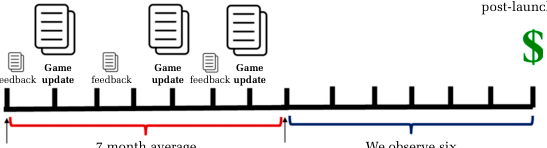

NOTE: figure/graphic rendered as an image from the PDF; its content is not machine-readable text. Caption (if any) follows as the next block.

**text found inside the figure**

feedback feedback

feedback

**Game update**

**Game update**

**Game update**

7 month average Early Access tenure

We observe six months post-launch

Outcome: Revenue six months

post-launch

#### **Steam Launch**

Note: In the cross-sectional analysis, we define feedback incorporation as the average similarity between firm game-update announcements and preceding user reviews during Early Access; the outcome is six months post-Early Access. In the panel analysis, feedback incorporation and outcomes are assessed month-by-month within Early Access.

8 We set the cutoff at six months to keep as many games as possible in the sample, while still leaving long enough to determine whether the game would be successful. As we show in Appendix D, the results are robust to using a one-year post-launch threshold (which reduces the sample to 309 games) and to a one-month post-launch threshold (which increases the sample to 536 games).

9 Only analyzing games that launch introduces potential endogeneity in the decision to launch. Specifically, if developers receive negative or difficult-to-implement feedback they might decide not to officially launch the game. As we elaborate below, we address this by (1) showing similar results using panel data during the Early Access period (which includes all games regardless of whether they launch); and (2) conducting a subsample analysis in Appendix D showing that games with positive feedback drove the results, thereby ruling out the negative feedback preventing launch scenario.

2026 Allen, Bremner, and McDonald 9

Page 10

incorporation of feedback from the previous month influences sales in the current month.

As in the cross-sectional analysis, it was necessary to drop games from the sample for which it was not possible to calculate our primary variables of interest. To construct this panel dataset, we started with the same sample of 2,507 Early Access games, totaling 30,207 game-month observations. We removed observations with fewer than five double-lagged monthly reviewers to analyze representativeness and ensure sufficient review text, reducing the sample to 1,299 games and 5,859 game-months.<sup>10</sup> We excluded gamemonths with a price of 0, and then we retained only those observations where the game had an update announcement in the preceding period, further reducing the sample to 872 games and 3,857 gamemonths. Finally, because it is not valid to conduct fixed-effects panel analysis on a game with a single observation, we removed games with only one observation. The final panel data sample comprised 538 games with 3,523 game-months.

Extension dataset: Video Game Insights and Steam API. To corroborate our main results with an independent and more up-to-date source, we assembled an extension dataset that combines the Video Game Insights database with data retrieved directly from the public Steam Web API. We began by scraping Video Game Insights’ Early Access games table to obtain the universe of titles that had ever participated in Early Access through the end of 2024, along with their Steam App IDs, price, all-time estimated revenue (as of August 2025), review counts, and developer or publisher identifiers. We then augmented these rows with per-game details from Video Game Insights’ game pages, including the first release date, Early Access exit date, and Steam tags. By combining these data sources, we were able to determine when each game was in Early Access, linked to its all-time revenue performance and basic descriptives.

Next, we scraped developer announcements and user reviews for each of these games during their Early Access period. Developer updates were pulled via the GetNewsForApp endpoint and restricted to “steam_community_announcements,” which we further limited to the Early Access window for

each game. User reviews were collected from Steam’s “appreviews” JSON endpoint and restricted to English-language reviews written during Early Access.

As in the primary dataset, we excluded free-to-play titles and required that a game have at least one developer announcement during Early Access and at least five Early Access reviews to ensure our variables are well defined. Using these data, we constructed the same two focal constructs as in the primary analysis, feedback incorporation and unrepresentativeness (described in the “Measures” section). Unlike our primary dataset, which allowed us to construct outcome performance measures over time, this dataset is only able to measure all-time commercial performance with Video Game Insights’ estimated revenue. Although this sacrifices the granularity needed to replicate all of our analyses, it enables verification of the main result, albeit with different measures, on an independent and more up-to-date dataset that extends through 2024. Additional collection and processing details appear in Appendix B.

Qualitative interview data. We supplemented our quantitative analyses with 29 first-hand interviews with firms (PC game developers), industry executives, and user community members; we also relied on archival interviews and blogs from Steam Early Access firms’ developers to triangulate our results (Wellman et al., 2023). The primary thrust of our interviews with firms and executives was twofold: (1) to understand the broader video-game industry, with a focus on use of market feedback; and (2) to understand the specifics of PC game development on Steam, especially when launching in Early Access. The interviews with Early Access user community members focused on (a) users’ motivations for participating in the game communities, and (b) the processes around giving feedback on games. These interviews helped to validate the empirical measures and to improve interpretation of the results.

Measures

Dependent variables. In our primary crosssectional dataset, we operationalize commercial performance for each new game as its base-game sales<sup>11</sup>

revenue during the first six months post-launch after leaving Early Access (post-launch revenue). We use

10 We again use five reviewers because, as in the crosssectional analysis, below five there will necessarily be a mechanical increase in unrepresentativeness (fewer than five reviewers cannot be representative of five customer segments). Nevertheless, for robustness, in Appendix D we show that the results hold for alternative thresholds: 3, 4, 5, 6, and 7.

11 In industry parlance, our measure captures only “base-game sales,” meaning the price paid for the game at the time of purchase, not revenue from subscription fees or extra-content sales (e.g., microtransactions).

10 Academy of Management Journal Month

Page 11

six months post-launch to include as many games as possible, while still observing a long enough postlaunch period to determine how successful the game was. As a robustness check, we use a one-year threshold and a one-month threshold; though it changes the sample, both specifications yield similar results (see Appendix D). In the panel analysis, we use monthly base-game revenue during Early Access.

Revenue from base-game sales is a primary indicator that firms use to assess their own performance. Recall that we excluded free games from the sample. To estimate revenue, we first calculated the average daily estimates of each game’s ownership numbers from SteamSpy over each calendar month (for additional details on the SteamSpy data-collection process, see Appendix A). Next, we identified the number of new owners by subtracting the average number of owners from the previous month. We then calculated revenue as the product of the change in owners and the average price for that month. In cases where the number of owners decreased, we set revenue to zero, as games would not lose base-game revenue due to players uninstalling them.

To test Hypothesis 2 regarding how feedback incorporation impacts positive within-community evaluations, we created the variable, within-community positivity, measured as the number of positive reviews divided by total reviews in the Early Access period. Note that we also use this as a control variable in some models, as described below.

Independent variable. The independent variable, feedback incorporation, uses cosine similarity between firm update announcements and user reviews to proxy the degree to which firms’ changes to the game reflected the preceding user-community feedback. Note that capturing the alignment of game changes with community feedback is distinct from quantifying the volume of feedback (which we include as a control). For each game-month, we assessed the similarity between the content of a game’s featureupdate announcements within that month and the text of users’ prior reviews (all during its Early Access phase). We constructed update texts by scraping SteamDB developer community announcements, tokenizing to sentences, and retaining sentences that signal substantive feature or gameplay changes,<sup>12</sup> which we

concatenated for each game-month. All prior user reviews up to, but not including, the current month were aggregated to create comparison texts (as we show in Appendix D, the results are robust to alternative lagging time windows including three, six, nine, and 12 months of prior reviews). Before computing similarity, we lower-cased all text, removed punctuation and stop words, and applied Porter stemming; tokenization was at the unigram level.

We then represented each document as a TF–IDFweighted vector (Singhal, 2001) using a corpus-wide vocabulary and inverse document frequencies computed over the full set of update and review documents to ensure comparability across titles and time (see Park et al., 2024). Operationalizing textual similarity as cosine similarity with TF–IDF word weighting is a standard approach in management and innovation research—for example, to compare similarities between crowdsourced ideas (Park et al., 2024), papers and patents (Arts, Cassiman & Gomez, 2018; Marx & Hsu, 2022), and research and development-project application texts (Criscuolo, Dahlander, Grohsjean & Salter, 2017).

Formally, cosine similarity is calculated for document d and term w, with weight as

(1)

where D j j is the number of documents and dfw the number containing w. Our similarity metric is cosine similarity between the update vector and the reviews vector: for game g in month t,

v<sup>update</sup>

g,t v<sup>reviews</sup>

||v<sup>update</sup>

g,t || ||v<sup>reviews</sup>

(2)

where D denotes the review window (one month for panel analyses; cumulative prior reviews up to, but excluding, month t for the cross-section; with varying time windows in robustness checks). A higher value indicates a greater degree of feedback incorporation. The measure was calculated in the cross-sectional data as the mean similarity between each month’s update text and cumulative prior reviews; in the panel data it was the mean similarity between the update text and the prior month’s reviews. We implemented the pipeline in R using “tidytext” for TF–IDF, 12 We used only sentences containing words that matched the following words (where represents a wildcard match): “add, new, feature, chang, now, introdu, no longer, experiment, try, is here, rebalanc.” This list was compiled by reading more than 300 announcements from a sample of developers to identify patterns associated

with new game features, changes, introductions, and additions. This filter excludes unrelated topics that occasionally appear in game-update announcements.

2026 Allen, Bremner, and McDonald 11

Page 12

“SnowballC” for stemming, and “lsa” for cosine similarity.

Figure 3 presents an illustrative example to help intuitively visualize what the feedback incorporation variable captures. Reviews that share salient terms with the developer (firm) update announcement score higher on cosine similarity and therefore receive a higher value for feedback incorporation. In the example in Figure 3, overlap terms such as “damage,” “balance,” and “orbs” increases similarity, indicating that developers are engaging with topics raised in user conversations.

Regarding robustness, results are consistent when varying the temporal window (e.g., cumulative prior vs. three months prior), and when logging the

similarity measure (for details and estimates, see Appendix D).

Moderator variable. To determine how unrepresentative the feedback-providing users in the community were relative to the broader market, we compared the distribution of users giving feedback on a game to the distribution of users in the market. To construct each distribution, we employed a K-means clustering algorithm to segment all Steam customers into distinct groups. We then calculated the measure unrepresentativeness as the degree to which the market-segment distribution of each game’s reviewers did not overlap with the overall customer base on Steam. See Figure 4 for an illustrative visual representation of the measure.

FIGURE 3 Illustrative Similarities between User Reviews and Developer (Firm) Update Announcement

#### **B**

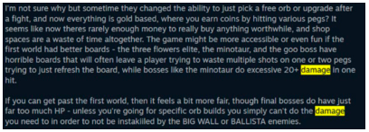

NOTE: figure/graphic rendered as an image from the PDF; its content is not machine-readable text. Caption (if any) follows as the next block.

#### **C**

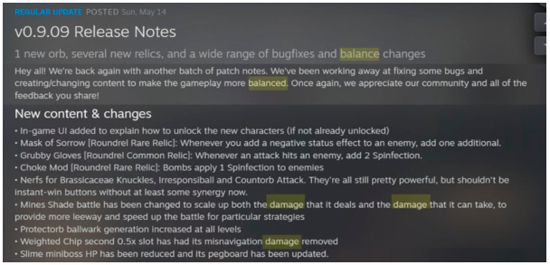

NOTE: figure/graphic rendered as an image from the PDF; its content is not machine-readable text. Caption (if any) follows as the next block.

12 Academy of Management Journal Month

Page 13

Although we do not directly observe the preferences of community users, we do observe their purchasing and interaction behaviors on the Steam platform. Under the reasonable assumption that purchasing and reviewing games from specific genres indicates a preference for those genres, we cluster users based on these and other observed behaviors. We define customer segments by categorizing all 4 million users on SteamDB into distinct market segments using a K-means clustering algorithm. The K-means algorithm is widely used for customer segmentation (Kansal, Bahuguna, Singh & Choudhury, 2018; Morwitz & Schmittlein, 1992; Pradana & Ha, 2021; Yau & Tang, 2018). It iteratively seeks distinct nonoverlapping subgroups for each data point in a way that minimizes variation within each group. Employing an unsupervised clustering algorithm to categorize reviewers allows us to assess representativeness without relying on our own subjective classifications. We had access to 42 user-level variables: 31 game-category variables (e.g., strategy, first-person shooter) that captured the number of games in each category that the user owned, the average positivity of the user’s reviews, the number of such reviews, the mean number of words per review, the percentage of games played that were in Early Access, the proportion of games purchased directly from Steam, the amount of time spent on the platform, the number of games purchased, the percentage of games acquired for free, the number of “helpful” and “funny” votes, and the number of comments.

Before applying the K-means algorithm, we used the Uniform Manifold Approximation and Projection (UMAP) algorithm to reduce the dimensionality of all the user-level variables from 42 dimensions to 10 (McInnes, Healy & Melville, 2018). Applying the K-means algorithm to the dimensionally reduced data, we identified five distinct market segments. These segments comprised groups whose members

were similar to each other but dissimilar to members of other groups. Key differences highlighted by the market segmentation included casual versus heavy gamers, the degree of active participation in reviews, and a preference for Early Access games. For instance, one segment consisted of casual gamers (characterized by low average gameplay) with minimal review participation. Another segment included heavy gamers with a high level of participation and a relatively large number of Early Access titles.

To calculate overlap between the market-segment distributions, we used the StatMatch package in R (D’Orazio, 2017). Formally, our unrepresentativeness measure in each game-month is calculated as one minus the statistical overlap between the distributions:

(3)

where each p1,j represents the relative frequencies of the game’s reviewers in each market segment j, and p2,j represents the relative frequencies of all Steam reviewers in each market segment j. Intuitively, if the distribution of a game’s reviewers to market segments were identical to that of the broader Steam population, its unrepresentativeness would be 0. If the distributions were as dissimilar as possible, its unrepresentativeness would be 1. Having assigned each user to a market segment, we calculated the mean unrepresentativeness for each game-month while in Early Access.

In the Appendix, we also use an alternative measure: the proportion of reviews contributed by users we classify as Early Access power users (power user %). Although this measure does not assess unrepresentativeness as directly as our primary measure, it neatly encapsulates a core issue highlighted in our study: the potential outsized influence of selfselected user communities on market feedback.

FIGURE 4 Illustration of Unrepresentativeness Measure

#### **A**

Segment 1

Segment 2

Segment 3

Segment 4

Segment 5

Segment 1

Segment 2

Segment 3

Segment 4

Segment 5

Segment 1

Segment 2

Segment 3

Segment 4

Segment 5

Proportion

of Users

#### **B C**

Note: Panel A 5 overall market (all Steam), Panel B 5 representative game community, Panel C 5 unrepresentative game community.

2026 Allen, Bremner, and McDonald 13

Page 14

Power users’ distinctive preferences are apt to become disproportionately salient to the firms. For additional details about the variable, and the results, see Appendix D.

Control variables. We included several control variables to rule out potential confounding explanations for the results. In the cross-sectional sample, each variable is calculated as the mean of its monthly values during the Early Access period. In the monthly panel sample, each variable is calculated as the monthly mean (during Early Access months). By controlling for these variables, we aim to isolate the effects on post-launch revenue from feedback incorporation and the user community’s unrepresentativeness.

First, we controlled for a game’s average price during Early Access. Price directly impacts the revenue outcome, and it is also often an indicator of a game’s depth, target audience, and production value. Second, because the quality or enjoyability of a game is a potential omitted variable that could affect both treatment (the feedback incorporation) and outcome (post-launch revenue), we also controlled for average within-community positivity toward a game, measured as the number of positive reviews divided by total reviews in the Early Access period. Third, we controlled for each game’s average monthly number of reviewers. This effectively controlled for the game’s volume of feedback and popularity during Early Access, which is likely to influence both the firm’s feedback incorporation and its game’s ultimate revenue after the official launch. Fourth, we controlled for the number of firm announcements during Early Access to disentangle firm activity in terms of frequency and volume from feedback incorporation as alignment with reviewer content. Finally, we controlled for firm experience as the number of prior games launched by the game’s developer firm, which helps to mitigate concerns around the potential alternative explanation that managerial or firm experience are confounding variables.

Our models also include several fixed effects. In the cross-sectional data, we added a fixed effect for the Early Access duration (in months) of the game prior to launch. The choice to launch quickly or to stay in for a long period could be an omitted variable, so we attempted to mitigate this potential confounder with fixed effects. We also added a fixed effect for the main game category (e.g., strategy, first-person shooter). This mitigates potential confounding by accounting for the fact that each category attracts a different type and size of audience. In robustness checks, we also used the more granular game tags as

fixed effects (see Appendix D). In the panel data, we used game and month fixed effects.

Statistical Estimation and Causality

To test our main hypothesis, we estimate a fixedeffects ordinary least squares (OLS) model that interacts user community unrepresentativeness and firm feedback incorporation in predicting the outcome of post-launch revenue. To identify the effect, we must validate the assumption that the interaction variables are exogenous. That is, we must assume that there is natural variation in a firm’s choice to align their feedback with user reviews, and this choice is based on unobserved factors that are not systematically related to the outcome of commercial success after adding controls. We also assume that unrepresentativeness corresponds to underlying game attributes and positioning that is not systematically related to commercial success, conditional upon important controls for community size and category fixed effects.

Given the necessity of exogeneity to identify our effect, the ideal empirical design would be to randomly assign varying degrees of feedback incorporation and community representativeness across games and compare their outcomes. Such a design was not feasible, and we did not have access to a valid exogenous shock or instrumental variable in our data. Therefore, when interpreting the results, it is important to consider potential endogeneity concerns. Reverse causality is not an issue; our dependent measure, post-launch revenue, is temporally sequenced after the independent and control variables. However, despite controlling for an array of observable confounders—including category fixed effects, prelaunch popularity, game quality, firm experience, and price—unobserved confounders might still create an endogenous relationship in firms’ propensity to incorporate to users’ feedback, or in the community’s representativeness, with regard to a game’s subsequent commercial performance.

14 Academy of Management Journal Month

Page 15

Additionally, we confirm that unrepresentativeness is not linked to lower positivity games (see the Results section), and that its negative impact on commercial success is pronounced only with high feedback incorporation (Appendix D), predominantly among positively received games (Appendix Table D5).

In the Appendix we conduct a range of additional robustness tests to address specific endogeneity concerns. For instance, we control for the mean similarity of reviews to ensure that our measure of feedback incorporation is not confounded by the coherence or agreement of the feedback, and for game novelty to rule out the alternative explanation that novel games evoke different types of feedback or less responsiveness from the firms. We also conduct subsample analyses based on how well the games were received within the community to rule out the alternative explanation that negative feedback leads to both less feedback incorporation and lower success. We provide further details in the “Robustness Checks” section.

Second, in addition to our primary cross-sectional analysis, we use a separate game-month panel dataset. The panel-data approach allows us to measure within-game effects, effectively eliminating timeinvariant game attributes that could act as potential omitted variables. For example, it removes any variance explained by the firm’s initial choice of positioning of the game as appealing to either a narrow or broad segment of the market. It also removes another source of potential endogeneity in the cross-sectional dataset: whether the game ever officially launches (in the cross-sectional data, we only observe Early Access games that “graduate”).

Finally, we use non-parametric covariate balance propensity score weighting to balance the observable confounders for our continuous-treatment variable feedback incorporation as well as for the moderator

variable unrepresentativeness (results displayed in Appendix D) (Imai & Ratkovic, 2014). Weighting allows us to effectively create a comparative set of games with analogous attributes during the Early Access phase to establish a counterfactual scenario in which all variables remain static except the feedback incorporation or unrepresentativeness variables. The steps we take to implement these methods are detailed in Appendix C.

RESULTS

Descriptives

TABLE 1 Summary Statistics

[output not shown]

NOTE: table converted from PDF layout to HTML text; cell boundaries are reconstructed. See PDF if exact alignment matters.

Notes: n 5 432. For panel data summary statistics, see Appendix A.

2026 Allen, Bremner, and McDonald 15

Page 16

Because of the heavily skewed distributions of post-launch revenue, reviewers, price, announcements, and experience, our primary analysis logs these variables to normalize the residuals, in accordance with the assumptions of OLS models (Wooldridge, 2010). We report non-logged results in Appendix D.

Before displaying the main results, we validate the underlying mechanism of self-selection with descriptives of customer positivity prior to and following official launch. According to our theory, users selfselect into communities, and thus they may not constitute a representative sample of the broader market of potential customers. Figure 5 presents evidence aligned with this proposed mechanism. The Early Access reviews (i.e., within-community evaluations)

were on average significantly more positive than reviews after the official launch (outside of the community). This is consistent with prior empirical work on Steam Early Access (Lin et al., 2019). As displayed in Figure 5, there was a 76%–78% mean positivity in Early Access from user community members, and only 66%–68% positive post-launch from finalproduct adopters. Next, we explore the implications of this self-selection.

Main Hypothesis Tests: Cross-Sectional Analysis

Table 3 reports the main results regarding how the interaction effect of a community’s unrepresentativeness with a firm’s feedback incorporation impact a game’s commercial success (Hypothesis 1).

TABLE 2 Correlations

|  |  |  | TABLE2 Correlations |  |  |  |  |  |
| --- | --- | --- | --- | --- | --- | --- | --- | --- |
|  | 1 | 2 | 3 | 4 | 5 | 6 | 7 | 8 |
| 1 Log (post-launch revenue) . | 1 |  |  |  |  |  |  |  |
| 2 Feedback incorporation . | 162 . | 1 |  |  |  |  |  |  |
| 3 Unrepresentativeness . | 2.196 | 2.157 | 1 |  |  |  |  |  |
| 4 Log (reviewers) . | 489 . | 282 . | 2.466 | 1 |  |  |  |  |
| 5 Log (price) . | 230 . | 270 . | 2.167 | 273 . | 1 |  |  |  |
| 6 Within-community positivity . | 108 . | 126 . | 00004 . | 037 . | 132 . | 1 |  |  |
| 7 Log (announcements) . | 255 . | 209 . | 2.201 | 443 . | 253 . | 120 . | 1 |  |
| 8 Log (experience) . | 184 . | 062 . | 2.051 | 150 . | 065 . | 2.022 | 051 . | 1 |
| 9 Early Access duration . | 2.025 | 017 . | 2.161 | 415 . | 183 . | 2.054 | 376 . | 2.047 |

NOTE: table converted from PDF layout to HTML text; cell boundaries are reconstructed. See PDF if exact alignment matters.

Note: These are the correlations for the cross-sectional data. For the panel data correlations, see Appendix A.

FIGURE 5 Positivity Reviews over Time among Early Access Community versus Post-Launch Users

0.80

0.78

0.76

0.74

Time (months)

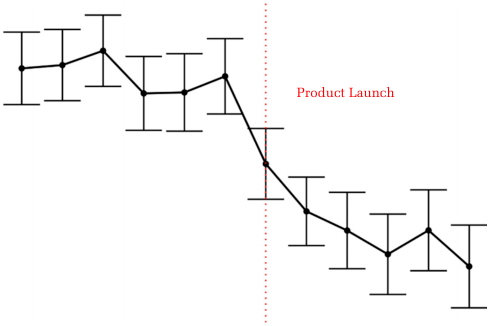

NOTE: figure/graphic rendered as an image from the PDF; its content is not machine-readable text. Caption (if any) follows as the next block.

**text found inside the figure**

Product Launch

–6 –5 –4 –3 –2 –1 0 1 2 3 4 5

0.72

0.70

0.68

Mean positive rating

0.66

0.64

0.62

16 Academy of Management Journal Month

Page 17

Each column reports coefficient estimates derived from OLS fixed-effect estimators using (logged) postlaunch revenue as the dependent variable. As a baseline, column 1 reports the results of a regression model that includes feedback incorporation and unrepresentativeness (without an interaction term), with no control variables. Without including important controls like community size, the coefficients indicate that a 1 standard deviation (SD) increase in feedback incorporation is associated with a 52% increase in revenue ðe<sup>0</sup><sup>:</sup><sup>422</sup>21 0:52Þ, while unrepresentativeness is associated with a 42% decrease in revenue.

Adding the interaction between feedback incorporation and unrepresentativeness in column 2 confirms our main moderating hypothesis (Hypothesis 1): the higher the value of unrepresentativeness, the more negative the effect of feedback incorporation on postlaunch revenue. Specifically, for a community with unrepresentativeness 1 SD above the mean, a 1 SD increase in feedback incorporation is associated with a

41.5% decrease ðe<sup>2</sup><sup>0</sup><sup>:</sup><sup>537</sup>21 20:415Þ in post-launch revenue.

TABLE 3 Cross-Sectional Tests of Hypothesis 1: Impact of Unrepresentativeness and Feedback Incorporation

on Revenue (Hypothesis 1)

| DependentVariable: Log (post-launch revenue) | (1) | (2) | (3) | (4) | (5) | (6) |
| --- | --- | --- | --- | --- | --- | --- |
| Feedbackincorporation | 422 . | 425 . | 2.094 | 2.095 | 2.060 | 029 . |
|  | (150) . | (143) . | (146) . | (146) . | (146) . | (132) . |
| Unrepresentativeness | 2.547 | 2.578 |  | 170 . | 099 . | 153 . |
| Feedbackincorporation3 | (164) . | (151) . 2.537 |  | (155) . | (158) . 2.343 | (153) . 2.417 |
| unrepresentativeness |  | (134) . |  |  | (156) . | (154) . |
| Log(reviewers) |  |  | 1159 . | 1216 . | 1130 . | 1234 . |
| Log(price) |  |  | (117) . 573 . | (132) . 588 . | (136) . 600 . | (128) . 566 . |
|  |  |  | (240) . | (237) . | (239) . | (240) . |
| Within-community positivity |  |  | 769 . | 771 . | 1012 . | 627 . |
|  |  |  | (760) . | (757) . | (747) . | (731) . |
| Log(announcements) |  |  | 329 . | 325 . | 294 . | 471 . |
|  |  |  | (230) . | (230) . | (228) . | (192) . |
| Log(experience) |  |  | 335† . | 328† . | 373 . | 288 . |
|  |  |  | (177) . | (176) . | (178) . | (181) . |
| CategoryFE |  |  | Yes | Yes | Yes | Yes |
| EarlyAccessdurationFE |  |  | Yes | Yes | Yes | Yes |
| Weights |  |  |  |  |  | YES |
| Numberofobservations | 432 | 432 | 432 | 432 | 432 | 432 |
| Adj R2 (full model) . | 052 . | 081 . | 356 . | 357 . | 367 . | 400 . |

NOTE: table converted from PDF layout to HTML text; cell boundaries are reconstructed. See PDF if exact alignment matters.

Note: To facilitate interpretation of the interaction term, Feedback Incorporation and Unrepresentativeness are z-score scaled and meancentered. For an explanation of the weighting procedure, including balance tests, see Appendix C. Robust standard errors appear in parentheses.

† p ,.10 p ,.05 p ,.01 p ,.001

2026 Allen, Bremner, and McDonald 17

Page 18

treatment weighting, with a coefficient of 20.417 on the interaction term.

We note that one potential alternative explanation of this empirical pattern could be that the controls mediate the impact of feedback incorporation on revenue—that firms judge early feedback as (un)representative, then seek additional reviews or change price and those actions drive performance. This explanation, however, is inconsistent with several other empirical observations. First, Table 4 (discussed below) shows that feedback incorporation predicts within-community positivity as theorized, but unrepresentativeness does not reliably predict either feedback incorporation or within-community positivity, which is inconsistent with the mediation explanation. Second, across specifications with controls, fixed effects, and covariate-balancing weights, the feedback incorporation 3 unrepresentativeness interaction in Table 3 remains with the predicted sign, underscoring that the estimand is the conditional effect rather than an unconditional feedback

incorporation main effect. Third, when we orthogonalize feedback incorporation to reviewer count and price (residualizing on these and other controls with fixed effects) and re-estimate the model, the statistically significant negative feedback incorporation 3 unrepresentativeness interaction persists. These patterns imply that the controls do not carry the effect, and are consistent with our theory that unrepresentativeness negatively moderates the effect of feedback incorporation.

Figure 6, which displays the marginal effects of the results reported in Table 3, assists in visualizing the results. It indicates that for “representative communities” (i.e., for games with the unrepresentativeness measure 2 SD below the mean), the marginal effect of feedback incorporation on revenue is strongly positive, while the marginal effect is strongly negative for “unrepresentative communities” (i.e., for games with the unrepresentativeness measure 2 SD above the mean).

In summary, the negative moderating effect of community representativeness on the relationship

TABLE 4 Cross-Sectional Tests of Hypothesis 2: Impact of Unrepresentativeness and Feedback Incorporation on

Within-Community Positivity (Hypothesis 2) and Testing Impact of Variables on Unrepresentativeness

and Feedback Incorporation

[output not shown]

NOTE: table converted from PDF layout to HTML text; cell boundaries are reconstructed. See PDF if exact alignment matters.

Note: To facilitate interpretation of the interaction term, Feedback Incorporation and Unrepresentativeness are z-score scaled and meancentered. Robust standard errors appear in parentheses.

† p ,.10 p ,.05 p ,.01 p ,.001

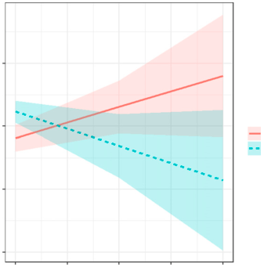

NOTE: figure/graphic rendered as an image from the PDF; its content is not machine-readable text. Caption (if any) follows as the next block.

between feedback incorporation and commercial success is robust across different model specifications. Regardless of whether control variables, weights, and fixed effects are included, the interaction term remains negative and statistically significant, indicating broad support for the moderating hypothesis (Hypothesis 1).

Next, we test hypothesis (Hypothesis 2): that there is a positive relationship between feedback incorporation and within-community positivity (the proportion of positive reviews within the community). We also conduct several post hoc analyses demonstrating that there is no observable relationship between the user community’s unrepresentativeness and the firm’s feedback incorporation, and that there is no observable relationship between the user community’s unrepresentativeness and within-community positivity. Table 4 reports these tests.

Table 4, columns 1 and 2 use within-community positivity as the dependent variable, measuring the product’s proportion of positive reviews within the community during the Early Access phase. As hypothesized by Hypothesis 2, there is a significant positive relationship between feedback incorporation and within-community positivity, even with all controls and fixed effects. Interestingly, Column 2 indicates that this effect persists and intensifies when

interacted with unrepresentativeness. Though not originally hypothesized, a plausible post hoc explanation could be that niche communities particularly value and respond more positively to a game tailored to their specific interests, because there are few other games that serve those particular interests (e.g., budgeting app super-users find it appealing when a firm finally builds an app that exactly serves their niche functionality demands).

Table 4, Column 3 indicates a null relationship between unrepresentativeness and feedback incorporation. This lack of significant findings suggests that a firm’s feedback incorporation does not depend on the user community’s unrepresentativeness. This is an important observation, because if firms knew to ignore feedback from these communities, then we would observe a relationship between unrepresentativeness and feedback incorporation, but we would likely not find support for our main hypothesis. It suggests either that firms cannot discern which communities are unrepresentative in this context (e.g., due to anonymous usernames), or that they have difficulty anticipating the downstream negative effects of incorporating feedback from unrepresentative communities. We suggest that the latter explanation is highly plausible, since firms receive short-term positive feedback within the community when they

FIGURE 6 Marginal Effect of Feedback Incorporation on Revenue for Unrepresentative versus Representative Communities

Representative Community Unrepresentative Community

Feedback Incorporation

Predicted Post-Launch Revenue (log)

0

5

10

15

Note: Based on the model in Table 3, Column 6. In the legend, Representative Community indicates marginal effects when the Unrepresentativeness measure is 2 SD below the mean, and Unrepresentative Community indicates marginal effects when the Unrepresentativeness measure is 2 SD above the mean.

incorporate suggestions (see columns 1 and 2), whereas the ultimate impact on a game’s commercial success is longer-term and less immediately evident.

This result also helps rule out the alternative explanation that games targeting narrow customer segments are simply more likely to fail and therefore more likely to spur feedback incorporation. The results from the model show that negative effects of unrepresentativeness arise only through its interaction with feedback incorporation. The critical issue, then, is not merely the association between unrepresentativeness and failure, but whether an omitted variable might simultaneously drive increased feedback incorporation, greater unrepresentativeness, and higher failure rates. Our analysis shows no evidence of a correlation between unrepresentativeness and feedback incorporation, suggesting that the interaction between these factors, rather than their individual presence, explains the observed patterns.

Finally, Table 4, Column 4 indicates a null relationship between the game’s within-community positivity and its unrepresentativeness, which casts doubt on the potential alternative explanation for our results that less well-received games might simply attract less representative community feedback. We also include a panel-data analysis in Appendix D that corroborates these findings from Table 4 at the gamemonth level.

Supplementary Tests: Panel-Data Analysis

We also conduct a panel-data analysis to supplement the primary cross-sectional analysis. The panel analysis estimates how firms’ monthly levels of feedback incorporation impact subsequent months’ commercial success for games while still in Early Access. Using a larger game-month panel dataset allows us to triangulate our cross-sectional results with additional data while controlling for time-invariant game attributes using game fixed effects. Although the outcome variable does not directly measure commercial success in the external market, increasing revenue from new users is an indication of a game’s increasing growth and success with users other than those who provided initial feedback.

Columns 6 and 7 of Table 5 mirror the specifications of columns 4 and 5, but replace the dependent variable log (revenue) with the percentage change in revenue from the prior month to the present month. This difference in revenues has the advantage of differencing out potential unobserved factors related to the initial popularity of the game. Consequently, the effects observed in these models specifically pertain to the growth of revenues at the game level from one month to the next. Despite this difference in the dependent variable, the significance of the terms and the models’ implications for supporting our hypothesis remain similar to those observed in the log (revenue) versions of the models.

Additional Robustness Checks

We conducted several analyses as additional robustness tests. Appendix D reports these results and provides additional details on how these analyses were conducted.

First, as an alternative measure of unrepresentativeness, we examine Early Access power users—the proportion of a game’s users who fall within the top 5% of Early Access participants. The results reinforce our theory: games with a high concentration of power users were less commercially successful when firms heavily incorporated their feedback. Power users are a valuable proxy for unrepresentativeness because their unusually high engagement in Early Access makes them systematically different from the broader

Steam market. They are likely more tolerant of unfinished products, and likely drawn to novelty or niche features that mainstream users may not value. As such, their feedback reflects atypical preferences. If firms rely too heavily on power users, they risk tailoring products to a narrow group of enthusiasts and alienating broader audiences. Observing the same negative moderation effect for power users strengthens our argument that feedback distortion arises whenever the community diverges from the general market, not only under one definition of unrepresentativeness.

Second, we report the regression models with a range of additional control variables and alternative specifications for variables used in the main analysis: (a) We control for the average similarity of reviews within each game, the novelty of the games, and the aggregate unrepresentativeness of the game’s category. (b) We control for each firm’s distribution capabilities and resources, which could influence both the community’s unrepresentativeness and the game’s commercial success. We created proxies of past success and distribution resources using the mean number of players of the firm’s prior games, and of the firm’s reputation

using the mean positivity of prior games. (c) To mitigate the potential confounding from game “tags,” which could either indicate popular games or the representativeness of the game’s audience, we control for over 90 user-categorized game tags. (d) We use observable confounders to weight the variable unrepresentativeness. (e) We use alternative measures of feedback incorporation focused on game content and gameplay.

Third, we report the results from regression models using non-logged variables, which corroborates the main results. Fourth, we report results using revenue from games one year after their official launch, and one month after their official launch. Although this changes the sample size (to 309 games for one-year and 536 for the one-month window), the findings corroborate the main results presented in the paper. The fact that the results hold across these varying shortterm to long-term windows also suggests that the results are not driven by firms learning and adapting after the official product launch.

Finally, we confirmed that the results were driven by games that had received positive feedback. One potential endogeneity concern could be that

TABLE 5 Panel Data Tests of Hypothesis 1: Impact of Unrepresentativeness and Feedback Incorporation

on Revenue (Hypothesis 1)

[output not shown]

NOTE: table converted from PDF layout to HTML text; cell boundaries are reconstructed. See PDF if exact alignment matters.

Note: to facilitate interpretation of the interaction term, Feedback Incorporation and Unrepresentativeness are z-score scaled and meancentered. For an explanation of the IPTW weighting, including balance tests, see Appendix C. Standard errors clustered at the game level appear in parentheses.

† p ,.10 p ,.05 p ,.01 p ,.001

poor-quality games are less enthusiastically received by users, which could be an omitted variable for firms incorporating less feedback and launching a less successful game. However, this concern is mitigated by the fact that the results appear to be driven by the most well-loved games among community members. In other words, as theorized, it appears to be the users who liked the games that lead to the detrimental incorporation of feedback by firms. We have included all of the above robustness checks, along with accompanying explanations, in Appendix D.

Extension Dataset Results

We also test Hypothesis 1 using the extension dataset compiled from Video Game Insights and the Steam API. Although this extension dataset lacks the granularity needed to reproduce all analyses and robustness checks in the paper, it allows us to verify the main result—using alternative measures—on an independent, more up-to-date dataset over 2,800 games that extends through 2024. As outlined in Appendix B, we constructed variables to mirror the methods used in the primary analysis.

Mirroring the Table 3 specification wherever possible, the analysis on the extension data corroborates the main result. As shown in Appendix B, for games with high levels of unrepresentativeness during early access, higher levels of feedback incorporation are associated with lower all-time revenue as of 2025 than games with lower levels of feedback incorporation. To view the results table and summary statistics for the extension dataset, see Appendix B.

Antecedents of Community Unrepresentativeness

Given our theory that the effectiveness of incorporating user community feedback hinges on the unrepresentativeness of the community, we consider: Which products under development attract unrepresentative communities in the first place? According to our theory, we expect that games that are initially niche-targeted or that appeal strongly to a particular type of user will attract an unrepresentative community. While we do not directly observe which games are niche-targeted, we assume in our analyses that it is these niche-appealing games that attract unrepresentative communities, and we base our theory on the observed data in the resulting community composition.

To increase the validity of these assumptions, we conducted an analysis demonstrating that the narrowness of the category in which the game is

launched predicts the community’s unrepresentativeness (for variable construction, see Appendix A). Although this measure does not fully capture how niche-targeted a game is, we observe that a 10% increase in category narrowness leads to a statistically significant 2.5% increase in the unrepresentativeness of the game’s user community (see Appendix D). We also observed that a higher price was associated with lower community unrepresentativeness. This is also unsurprising—in the context of the video-game market, price is one of the primary indicators of production value and of the expectation for widespread commercial success, which would be likely to positively correlate with broad appeal.

We also found that a game’s novelty (measured using category-spanning, as in McDonald & Allen, 2022; see measure description in Appendix A) was positively correlated with unrepresentativeness, although this relationship was not statistically significant (see Appendix D). In a separate analysis, however, we found that our theory was more strongly supported among less novel games (Appendix D). This stronger support among less novel games suggests a potential boundary condition of our theory: the detrimental impact of unrepresentative feedback may be particularly critical for the majority of products which are not highly novel, which depend heavily on easily observable broad market appeal for commercial success.

We claim not that a game’s narrow category membership fully predicts its community’s unrepresentativeness, but that it is indicative of a game’s niche appeal, which in turn attracts an unrepresentative community. Therefore, our main analysis measures the community unrepresentativeness as the indicator of some upstream characteristic of the game (e.g., narrow category membership or targeting a particular type of user) that led it to strongly attract a certain type of user. We return to these results in the “Discussion” section as we discuss implications for decision-makers.

DISCUSSION

In this paper, we developed theory describing when incorporation of feedback from user communities in product development undermines commercial success. While incorporating more feedback unambiguously enhances positive evaluations within the community, we proposed that self-selection of users into the community can create a scenario where more feedback incorporation systematically diminishes commercial performance outside the community.

This occurs for products that attract communities characterized by a strong self-selection of users that are unrepresentative of the broader market. Heavily incorporating such feedback leads firms to cater to specific user preferences that fail to transfer to the broader population, limiting mainstream commercial success. In the context of PC game development, we presented empirical evidence consistent with our theory. We found that, independent of community size, community unrepresentativeness had a strong, negative moderation effect on the relationship between feedback incorporation and commercial success (outside the community). This negative moderating effect produces a systematic negative impact from feedback incorporation when communities are highly unrepresentative (even when large). Conversely, we observed a positive relationship between feedback incorporation and positive evaluations within the community.

We also addressed the question of why firms would incorporate feedback that harms commercial success. We presented evidence suggesting that detecting and adapting to unrepresentative feedback is challenging for firms: we found no relationship between community unrepresentativeness and feedback incorporation. In this setting (as in other entrepreneurship contexts), firms have limited control over who provides feedback, and few resources for traditional market research. For such firms, immediate positive responses from community users may be a more salient signal than the longer-term lack of success in the broader market. Overall, these findings support our theory and contribute to user community innovation, data-driven entrepreneurship, and organizational search literatures.

Implications for Theories of Firm–Community Innovation

Prior research highlights benefits for firms leveraging user communities in several product-development phases, including ideation (Bayus, 2013; Lilien et al., 2002; Park et al., 2024; Piezunka & Dahlander, 2015, 2019; Poetz & Schreier, 2012; Schweisfurth, 2017), development (Dahlander & Magnusson, 2005; Dahlander & Wallin, 2006; Nagle, 2018, 2019), and commercialization (Baldwin et al., 2006; Baldwin & von Hippel, 2011; Bremner & Eisenhardt, 2021; Shah & Tripsas, 2007). These interactions enable firms to develop more innovative and higher-performing products versus innovating on their own.

However, our theory and findings point to a significant boundary condition to the benefits of firm–community innovation. We show that such collaborations in the

market feedback phase, when firms solicit feedback from communities about features and functionalities of their partially developed products, may actually undermine the commercial success of new products. Products with strong selection pressure for a particular user type may receive rich and informed feedback from self-selected users, yet these community members likely possess preferences that are unrepresentative of the broader market, producing a negative relationship between feedback incorporation and commercial success. As one game designer warned: “Listen to your community. But I would also say: know when not to listen.”

Our empirical analysis of antecedents influencing community unrepresentativeness shows that products targeting narrow categories or those positioned as lower-priced (potentially indicating lower production value) tend to attract less representative user communities. While niche appeal alone need not mean these products will be less commercially successful (Allen, 2025; Christensen & Bower, 1996; Christensen, McDonald, Altman & Palmer, 2018; Rogers, 2003), our theory suggests that decision-makers would be more likely to develop a commercially successful product by ignoring community feedback for games with niche appeal—at least until the product attracts more representative, mainstream users.

Therefore, while prior research suggests that feedback from lead users significantly benefits innovation in emerging technologies (Urban & von Hippel, 1988; von Hippel, 1986), our results challenge these benefits in more established markets. In such markets, our theory suggests that feedback from self-selected users— even those with advanced knowledge and expertise— can harm firms seeking commercial success.

Implications for Theories of Data-Driven Strategy and Entrepreneurship

Prior studies within the strategy and entrepreneurship literature demonstrate the importance of gathering information about market preferences in innovation (Allen & McDonald, 2025; Camuffo et al., 2020; Gans et al., 2019; Gao & McDonald, 2019; Koning et al., 2022; Morris et al., 2023). This work suggests that feedback about a nascent product, whether positive or negative, benefits firms: positive feedback confirms that innovators are on track while negative feedback signals a need to quit or pivot (McDonald & Gao, 2019).

However, our theory identifies an underappreciated counterpoint: more information about early customers can actually be detrimental to innovation

success. We demonstrate that when feedback comes from an unrepresentative sample, firms may discard product features that would appeal to a broader audience (Type I error) or focus on niche features that do not resonate with other potential customers (Type II error).

That unrepresentative samples lead to incorrect inferences is established (Cao et al., 2021; Denrell, 2003; Denrell & Kovacs, 2008). Yet, our findings contribute by emphasizing that in product development with user community feedback, unrepresentativeness can be systematic (not merely noisy), difficult to detect, and challenging to mitigate. We found no clear link between community representativeness and the extent to which game-producing firms incorporated that community’s feedback. This pattern suggests that firms either do not fully understand how well their user communities’ preferences reflect the broader market (due to limited resources or user anonymity), or struggle to filter or adapt feedback (due to salient, often positive, within-community signals).

While most innovation and entrepreneurship does not involve formal user communities, many entrepreneurial settings nonetheless exhibit similar feedbackgeneration characteristics: a convenience bias in user selection, a lack of control over the sample using the early product, and limited resources for traditional market research. Given these parallels, our theory suggests that startup founders may need to be cautious of self-selected advice, particularly when developing products that are likely to initially attract niche users.

These observations also invite future research on whether artificial intelligence, which will be increasingly used to interpret early user signals and guide product and strategy choices (Allen & McDonald, 2026), will overweight data from self-selected early adopters and thereby reinforce the same errors we identify.

Implications for Theories of Organizational Search

As a broader theoretical contribution to organizational theories of search, we highlight the need to distinguish between supply-side knowledge recombination and demand-side customer validation. A long-standing body of literature has shown that external search mechanisms like crowdsourcing, alliances, or open-source development help to overcome the local myopia of supply-side knowledge recombination (Afuah & Tucci, 2012; Keil, 2002; Keil, Maula, Schildt & Zahra, 2008; Levinthal & March

1993; Park et al., 2024; Rosenkopf & Almeida, 2003; Rosenkopf & Nerkar, 2001). This positive view developed within contexts where organizations build new technologies or solutions that require external knowledge or complex problem-solving (Dahlander & Wallin, 2006; Jeppesen & Molin, 2003; Lakhani & von Hippel, 2003; Nagle, 2019; O’Mahony, 2003; O’Mahony & Lakhani, 2011; Shah & Tripsas, 2007). External search can significantly enhance an organization’s capability to navigate technological uncertainties by generating a broad array of potential innovations, termed “long jumps,” that would not be possible within a firm’s boundaries (Baldwin & von Hippel, 2011; Bremner & Eisenhardt, 2021; Felin & Zenger, 2014; Levinthal, 2021: 78; Nagle, 2018). Communities involved in product development benefit, for instance, from the diverse skills, knowledge, and expertise of users who opt to participate.

However, our study again suggests caution when applying supply-side logic to demand-side search, such as customer validation for achieving commercial success. While user-led external search benefits knowledge recombination, it may adversely skew market learning. According to our study, this misalignment stems from self-selected contributors who, though highly knowledgeable and enthusiastic about the focal domain, may lack mechanisms to ensure that their preferred features also appeal to a broader, mainstream audience. Our findings suggest that focusing solely on whether a community of users can attain what they want, without considering broader market appeal, jeopardizes commercial success. In other words, traditional search paradigms resolve “Can we build what we want?” but cannot fully address “Will what we build have broad appeal?” Future research can further explore how the classical organizational search paradigms face limitations when guiding decision-makers in contexts where resolving market uncertainty outweighs resolving technological uncertainty.

Limitations and Future Directions

Several boundary conditions of our theory remain for future research. First, our observations address only later stages of selection and development for products already being launched, not initial product-concept generation (Criscuolo et al., 2017; Keum & See, 2017). Our results do not imply that user communities (a) generating ideas for their own use or (b) engaging with firms in earlier development stages (ideation) necessarily harm commercial success.

Second, in other contexts, incorporating unrepresentative user feedback could yield neutral—or even positive—commercial outcomes. Our empirical setting examined a mature marketplace with established categories and expectations. By contrast, as our analysis of novelty suggests (Appendix D), in highly novel or ambiguous contexts, unrepresentative feedback may prove valuable, as lead users can provide forwardlooking insights that diffuse more broadly over time (Allen, 2025; Moore, 1991). Our results may also depend on the heterogeneity and fragmentation of preferences in a market. In our context, success requires big hits appealing to a large base of gamers with heterogeneous preferences. In other contexts, with relatively homogeneous preferences, unrepresentativeness may be less consequential; or, where success requires niche appeal, tailoring products to small clusters may prove advantageous (Akcigit & Kerr, 2018).

Third, we must better understand antecedents of community unrepresentativeness. Our post hoc analyses indicate that product category and price influence unrepresentativeness; however, further research could explore how a product’s design, attributes, and positioning attract unrepresentative users. For example, unrepresentative users may emerge from mechanics rewarding mastery, the signaling aesthetic (e.g., retro pixel art), narrow platform or language support (PC-only, English-only), higher price points, and marketing through hardcore subcommunities (tags like “difficult,” influencer channels, invite-only Discords). Such choices may disproportionately attract expert enthusiasts, but our data limitations preclude deeper analysis, warranting further exploration.

Finally, our analysis does not account for development costs. Even if incorporating feedback reduces revenue, it may still improve profitability by lowering costs (Baldwin & von Hippel, 2011; Bremner & Eisenhardt, 2021; Felin & Zenger, 2014; Lakhani, Lifshitz- Assaf & Tushman, 2013). While our study cannot conclusively assess profitability, it identifies the tradeoff firms face: potential revenue losses versus efficiency gains from relying on community feedback.

REFERENCES

Afuah, A., & Tucci, C. L. 2012. Crowdsourcing as a solu-

tion to distant search. Academy of Management Review, 37: 355–375.

Akcigit, U., & Kerr, W. R. 2018. Growth through heteroge-

neous innovations. Journal of Political Economy, 126: 1374–1443.

Allen, R. T. 2025. Leap of faith? How diffusion dynam-

ics obfuscate the commercial potential of novel

innovations. SSRN. Retrieved from https://papers.ssrn. com/sol3/papers.cfm?abstract_id=5084612.

Allen, R. T., & McDonald, R. 2026. How well can AI do

strategy? Empirical benchmarking using strategy simulations. Strategy Science. doi:10.1287/stsc.2025. 0444

Allen, R. T., & McDonald, R. M. 2025. Methodological plu-

ralism and innovation in data-driven organizations. Administrative Science Quarterly, 70: 403–443.

Arts, S., Cassiman, B., & Gomez, J. C. 2018. Text matching

to measure patent similarity. Strategic Management Journal, 39: 62–84.

Autio, E., Dahlander, L., & Frederiksen, L. 2013. Informa-

tion exposure, opportunity evaluation, and entrepreneurial action: An investigation of an online user community. Academy of Management Journal, 56: 1348–1371.

Bailey, E., & Miyata, K. 2019. Improving video game pro-

ject scope decisions with data: An analysis of achievements and game completion rates. Entertainment Computing, 31: 100299.

Baldwin, C., Hienerth, C., & von Hippel, E. A. 2006. How

user innovations become commercial products: A theoretical investigation and case study. Research Policy, 35: 1291–1313.

Baldwin, C., & von Hippel, E. 2011. Modeling a paradigm

shift: From producer innovation to user and open collaborative innovation. Organization Science, 22: 1399–1417.

Bayus, B. L. 2013. Crowdsourcing new product ideas over

time: An analysis of the Dell IdeaStorm community. Management Science, 59: 226–244.

Bremner, R. P., & Eisenhardt, K. M. 2021. Organizing form,

experimentation, and performance: Innovation in the nascent civilian drone industry. Organization Science, 33: 1251–1699.

Brunt, C. S., King, A. S., & King, J. T. 2020. The influence

of user-generated content on video game demand. Journal of Cultural Economics, 44: 35–56.

Camuffo, A., Cordova, A., Gambardella, A., & Spina, C.

2020. A scientific approach to entrepreneurial decision making: Evidence from a randomized control trial. Management Science, 66: 564–586.

Cao, R., Koning, R. M., & Nanda, R. 2021. Biased sampling

of early users and the direction of startup innovation. Working paper no. 28882, NBER. Retrieved from https://www.nber.org/system/files/working_papers/ w28882/revisions/w28882.rev0.pdf

Carroll, G. R. 1985. Concentration and specialization:

Dynamics of niche width in populations of organizations. American Journal of Sociology, 90: 1262–1283.

Casella, G., & Berger, R. 2024. Statistical inference. New

York: CRC.

Chatterji, A. K., & Fabrizio, K. R. 2014. Using users: When

does external knowledge enhance corporate product innovation? Strategic Management Journal, 35: 1427–1445.

Chen, E. L., Katila, R., McDonald, R., & Eisenhardt, K. M.

2010. Life in the fast lane: Origins of competitive interaction in new vs. Established markets. Strategic Management Journal, 31: 1527–1547.

Christensen, C. M., & Bower, J. L. 1996. Customer power,

strategic investment, and the failure of leading firms. Strategic Management Journal, 17: 197–218.

Christensen, C. M., McDonald, R., Altman, E. J., & Palmer,

J. E. 2018. Disruptive innovation: An intellectual history and directions for future research. Journal of Management Studies, 55: 1043–1078.

Contigiani, A., & Levinthal, D. A. 2019. Situating the con-

struct of lean start-up: Adjacent conversations and possible future directions. Industrial and Corporate Change, 28: 551–564.

Criscuolo, P., Dahlander, L., Grohsjean, T., & Salter, A.

2017. Evaluating novelty: The role of panels in the selection of R&D projects. Academy of Management Journal, 60: 433–460.

Dahlander, L., & Magnusson, M. G. 2005. Relationships

between open source software companies and communities: Observations from Nordic firms. Research Policy, 34: 481–493.

Dahlander, L., & Wallin, M. W. 2006. A man on the inside:

Unlocking communities as complementary assets. Research Policy, 35: 1243–1259.

David, P. A., & Shapiro, J. S. 2008. Community-based pro-

duction of open-source software: What do we know about the developers who participate? Information Economics and Policy, 20: 364–398.

Denrell, J. 2003. Vicarious learning, undersampling of fail-

ure, and the myths of management. Organization Science, 14: 227–243.

Denrell, J., Fang, C., & Winter, S. G. 2003. The economics

of strategic opportunity. Strategic Management Journal, 24: 977–990.

Denrell, J., & Kovacs, B. 2008. Selective sampling of empir-

ical settings in organizational studies. Administrative Science Quarterly, 53: 109–144.

D’Orazio, M. 2017. Statistical matching and imputation of

survey data with StatMatch. Rome: Italian National Institute of Statistics.

Edwards, C. 2013. November 4: Valve lines up console

partners in challenge to Microsoft Sony. Bloomberg Business.

Felin, T., & Zenger, T. R. 2014. Closed or open innovation?

Problem solving and the governance choice. Research Policy, 43: 914–925.

Feller, W. 1991. An introduction to probability theory

and its applications, volume 2. New York: John Wiley & Sons.

Foss, N. J., Laursen, K., & Pedersen, T. 2011. Linking cus-

tomer interaction and innovation: The mediating role of new organizational practices. Organization Science, 22: 980–999.

Gans, J. S., Stern, S., & Wu, J. 2019. Foundations of entre-

preneurial strategy. Strategic Management Journal, 40: 736–756.

Gao, C., & McDonald, R. 2019. Shaping nascent industries:

Innovation strategy and regulatory uncertainty in personal genomics. Administrative Science Quarterly, 67: 915–967.

Gavetti, G. 2012. Toward a behavioral theory of strategy.

Organization Science, 23: 267–285.

Hall, C. 2015. Steam Spy scrapes Steam user accounts to

estimate sales data. Polygon.

Harhoff, D., & Lakhani, K. R. 2016. Revolutionizing inno-

vation: Users, communities, and open innovation. Cambridge, MA: MIT Press.

Heckman, J. J. 1979. Sample selection bias as a specifica-

tion error. Econometrica, 47: 153–161.

Hippel, E. V., & Krogh, G. V 2003. Open source software

and the “private-collective” innovation model: Issues for organization science. Organization Science, 14: 209–223.

Hruska, J. 2018. Steam earned an estimated $4.3B in 2017,

but benefits flow to handful of titles. Extreme Tech.

Imai, K., & Ratkovic, M. 2014. Covariate balancing pro-

pensity score. Journal of the Royal Statistical Society: Series B (Statistical Methodology), 76: 243–263.

Jeppesen, L. B., & Molin, M. J. 2003. Consumers as co-

developers: Learning and innovation outside the firm. Technology Analysis & Strategic Management, 15: 363–383.

Kansal, T., Bahuguna, S., Singh, V., & Choudhury, T. 2018.

Customer segmentation using K-means clustering. In Proceedings of the 2018 International Conference on Computational Techniques, Electronics and Mechanical Systems (CTEMS): 135–139. Piscataway, NJ: IEEE.

Katila, R., Piezunka, H., Reineke, P., & Eisenhardt, K. M.

2022. Big fish versus big pond? Entrepreneurs, established firms, and antecedents of tie formation. Academy of Management Journal, 65: 427–452.

Katila, R., Thatchenkery, S., Christensen, M. Q., & Zenios,

S. 2017. Is there a doctor in the house? Expert product users, organizational roles, and innovation. Academy of Management Journal, 60: 2415–2437.

Keil, T. 2002. External corporate venturing: Strategic

renewal in rapidly changing industries. Westport, CT: Quorum Books.

Keil, T., Maula, M., Schildt, H., & Zahra, S. A. 2008. The

effect of governance modes and relatedness of external business development activities on innovative performance. Strategic Management Journal, 29: 895–907.

Keum, D., & See, K. E. 2017. The influence of hierarchy on

idea generation and selection in the innovation process. Organization Science, 28: 653–669.

Koning, R., Hasan, S., & Chatterji, A. 2022. Experimenta-

tion and startup performance: Evidence from A/B testing. Management Science, 68: 6434–6453.

Krishna, V., Shrestha, Y. R., & von Krogh, G. 2024. “The

double-edged sword of inflated help”: Unravelling the motivation crowding in community questionanswering platforms. PLOS One, 19: e0297627.

Lakhani, K. R. 2016. Managing communities and contests

to innovate with crowds. In D. Harhoff & K. R. Lakhani (Eds.), Revolutionizing innovation: Users, communities, and open innovation: 109–134. Cambridge, MA: MIT Press.

Lakhani, K. R., Lifshitz-Assaf, H., & Tushman, M. L. 2013.

Open innovation and organizational boundaries: Task decomposition, knowledge distribution and the locus of innovation. In A. Grandori (Ed.), Handbook of economic organization: Integrating economic and organization theory: 355–382. Cheltenham, U.K.; Northampton, MA: Edward Elgar.

Lakhani, K. R., & von Hippel, E. 2003. How open source

software works: “Free” user-to-user assistance. Research Policy, 32: 923–943.

Lakhani, K. R., & Wolf, R. G. 2005. Why hackers do what

they do: Understanding motivation and effort in free/open source software projects. In J. Feller, B. Fitzgerald, S. A. Hissam, & K. R. Lakhani (Eds.), Perspectives on free and open source software: 3–22. Cambridge, MA: MIT Press.

Levinthal, D. A. 2021. Evolutionary processes and orga-

nizational adaptation: A Mendelian perspective on strategic management. Oxford: Oxford University Press.

Levinthal, D. A., & March, J. G. 1993. The myopia of learn-

ing. Strategic Management Journal, 14: 95–112.

Lilien, G. L., Morrison, P. D., Searls, K., Sonnack, M., &

Hippel, E. V 2002. Performance assessment of the lead user idea-generation process for new product development. Management Science, 48: 1042–1059.

Lin, D., Bezemer, C.-P., Zou, Y., & Hassan, A. E. 2019. An

empirical study of game reviews on the steam platform. Empirical Software Engineering, 24: 170–207.

MacCormack, A., Verganti, R., & Iansiti, M. 2001. Develop-

ing products on “internet time”: The anatomy of a

flexible development process. Management Science, 47: 133–150.

Marx, M., & Hsu, D. H. 2022. Revisiting the entrepreneurial

commercialization of academic science: Evidence from “twin” discoveries. Management Science, 68: 1330–1352.

McDonald, R. M., & Allen, R. T. 2022. A spanner in the

works: Category-spanning entrants and audience valuation of incumbents. Strategy Science, 7: 190–209.

McDonald, R. M., & Eisenhardt, K. M. 2019. Parallel play:

Startups, nascent markets, and effective businessmodel design. Administrative Science Quarterly, 65: 483–523.

McDonald, R. M., & Gao, C. 2019. Pivoting isn’t enough?

Managing strategic reorientation in new ventures. Organization Science, 30: 1289–1318.

McInnes, L., Healy, J., & Melville, J. 2018. UMAP: Uniform

manifold approximation and projection for dimension reduction. arXiv:1802.03426.

Meer, A. 2019. Half of all games on steam came out since

2017. Rock Paper Shotgun. Retrieved from https:// www.rockpapershotgun.com/2019/01/15/how-manygames-are-on-steam/.

Mollick, E. 2012. People and process, suits and innovators:

The role of individuals in firm performance. Strategic Management Journal, 33: 1001–1015.

Mollick, E. 2016. Filthy lucre? Innovative communities,

identity, and commercialization. Organization Science, 27: 1472–1487.

Moore, G. A. 1991. Crossing the chasm: Marketing and

selling high-tech products to mainstream customers. New York: HarperBusiness.

Morris, S., Oldroyd, J., Allen, R. T., Chng, D. H. M., & Han,

J. 2023. From local modification to global innovation: How research units in emerging economies innovate for the world. Journal of International Business Studies, 54: 418–440.

Morwitz, V. G., & Schmittlein, D. 1992. Using segmenta-

tion to improve sales forecasts based on purchase intent: Which “intenders” actually buy? Journal of Marketing Research, 29: 391–405.

Murray, F., & Tripsas, M. 2004. The exploratory processes

of entrepreneurial firms: The role of purposeful experimentation. In J. A. C. Baum & A. M. McGahan (Eds.), Business strategy over the industry life cycle: 45–75. Oxford, U.K.: Elsevier JAI.

Nagle, F. 2018. Learning by contributing: Gaining com-

petitive advantage through contribution to crowdsourced public goods. Organization Science, 29: 569–587.

Nagle, F. 2019. Open source software and firm productiv-

ity. Management Science, 65: 1191–1215.

O’Mahony, S. 2003. Guarding the commons: How commu-

nity managed software projects protect their work. Research Policy, 32: 1179–1198.

O’Mahony, S., & Lakhani, K. R. 2011. Organizations in the

shadow of communities. In C. Marquis, M. Lounsbury, & R. Greenwood (Eds.), Communities and organizations, research in the sociology of organizations, vol. 33: 3–36. Bingley, U.K.: Emerald Group Publishing.

Orland, K. 2014. Introducing Steam Gauge: Ars reveals

Steam’s most popular games. Ars Technica.

Osterloh, M., & Rota, S. 2007. Open source software

development—Just another case of collective invention? Research Policy, 36: 157–171.

Park, S., Piezunka, H., & Dahlander, L. 2024. Coevolution-

ary lock-in in external search. Academy of Management Journal, 67: 262–288.

Piezunka, H., & Dahlander, L. 2015. Distant search, narrow

attention: How crowding alters organizations’ filtering of suggestions in crowdsourcing. Academy of Management Journal, 58: 856–880.

Piezunka, H., & Dahlander, L. 2019. Idea rejected, tie

formed: Organizations’ feedback on crowdsourced ideas. Academy of Management Journal, 62: 503–530.

Plunkett, L. 2013. Steam is 10 today. Remember when it

sucked? Kotaku US.

Poetz, M. K., & Schreier, M. 2012. The value of crowdsour-

cing: Can users really compete with professionals in generating new product ideas? Journal of Product Innovation Management, 29: 245–256.

Pradana, M. G., & Ha, H. T. 2021. Maximizing strategy

improvement in mall customer segmentation using K-means clustering. Journal of Applied Data Sciences, 2: 19–25.

Preece, J., Nonnecke, B., & Andrews, D. 2004. The top five rea-

sons for lurking: Improving community experiences for everyone. Computers in Human Behavior, 20: 201–223.

Pritchett, L., & Sandefur, J. 2015. Learning from experi-

ments when context matters. American Economic Review, 105: 471–475.

Puranam, P., Alexy, O., & Reitzig, M. 2014. What’s “new”

about new forms of organizing? Academy of Management Review, 39: 162–180.

Riggs, W., & von Hippel, E. 1994. Incentives to innovate

and the sources of innovation: The case of scientific instruments. Research Policy, 23: 459–469.

Rogers, E. M. 2003. Diffusion of innovations (5th ed.).

New York: Simon and Schuster.

Rosenkopf, L., & Almeida, P. 2003. Overcoming local

search through alliances and mobility. Management Science, 49: 751–766.

Rosenkopf, L., & Nerkar, A. 2001. Beyond local search:

Boundary-spanning, exploration, and impact in the

optical disk industry. Strategic Management Journal, 22: 287–306.

Schweisfurth, T. G. 2017. Comparing internal and external

lead users as sources of innovation. Research Policy, 46: 238–248.

Shah, S. 2005. Open beyond software. Open Sources, 2:

339–360.

Shah, S. 2006. Motivation, governance, and the viability of

hybrid forms in open source software development. Management Science, 52: 1000–1014.

Shah, S., & Nagle, F. 2020. Why do user communities mat-

ter for strategy? Strategic Management Review, 1: 305–353.

Shah, S., & Tripsas, M. 2007. The accidental entrepreneur:

The emergent and collective process of user entrepreneurship. Strategic Entrepreneurship Journal, 1: 123–140.

Singhal, A. 2001. Modern information retrieval: A brief

overview. IEEE Data Engineering Bulletin, 24: 35–43.

Smith, S. W., & Shah, S. K. 2013. Do innovative users gener-

ate more useful insights? An analysis of corporate venture capital investments in the medical device industry. Strategic Entrepreneurship Journal, 7: 151–167.

Steam. n.d. Steam support: Early access. Retrieved from

https://help.steampowered.com/en/faqs/view/6554- ED29-FBDB-1612

Steamworks. 2014. Early access. Retrieved from https://

partner.steamgames.com/doc/store/earlyaccess

Toh, P. K., & Kim, T. 2013. Why put all your eggs in

one basket? A competition-based view of how technological uncertainty affects a firm’s technological specialization. Organization Science, 24: 1214–1236.

Urban, G. L., & von Hippel, E. 1988. Lead user analyses for

the development of new industrial products. Management Science, 34: 569–582.

von Hippel, E. 1986. Lead users: A source of novel product

concepts. Management Science, 32: 791–805.

Von Krogh, G., Haefliger, S., Spaeth, S., & Wallin, M. W.

2012. Carrots and rainbows: Motivation and social practice in open source software development. MIS Quarterly, 36: 649–676.

Von Krogh, G., Spaeth, S., & Lakhani, K. R. 2003. Commu-

nity, joining, and specialization in open source software innovation: A case study. Research Policy, 32: 1217–1241.

Wellman, N., Tröster, C., Grimes, M., Roberson, Q.,

Rink, F., & Gruber, M. 2023. Publishing multimethod research in AMJ: A review and best-practice recommendations. Academy of Management Journal, 66: 1007–1015.

Wijman, T. 2018. Mobile revenues account for more than

50% of the global games market as it reaches $137.9 billion in 2018. Newzoo.

Wooldridge, J. M. 2010. Econometric analysis of cross

section and panel data. Cambridge, MA: MIT Press.

Yau, H. K., & Tang, H. Y. H. 2018. Analyzing ecology

of internet marketing in small-and medium-sized enterprises (SMEs) with unsupervised-learning algorithm. Journal of Marketing Analytics, 6: 53–61.

Zhao, E. Y., Ishihara, M., Jennings, P. D., & Lounsbury, M.

2018. Optimal distinctiveness in the console video game industry: An exemplar-based model of protocategory evolution. Organization Science, 29: 588– 611.

Ryan T. Allen (ryan.allen@byu.edu) is an assistant professor of strategy at Brigham Young University’s Marriott School of Business. He studies how organizations use

data to make decisions that shape strategy and innovation. He received his PhD in business administration from Harvard Business School.

Robert Bremner (rbremner@alumni.stanford.edu) is a senior director of market intelligence at Microsoft. Previously, he was head of strategic analytics and intelligence at Electronic Arts. He received his PhD in management science and engineering from Stanford University’s Technology Ventures Program, where his dissertation focused on organizational forms and strategic decisionmaking in nascent industries.

Rory M. McDonald (mcdonaldr@darden.virginia.edu) is the John Tyler Associate Professor of Business Administration at the University of Virginia’s Darden School of Business. He studies how firms navigate nascent industries and product categories. He received his PhD in management science and engineering from Stanford University’s Technology Ventures Program.